# trabalho-final

Eduardo Ouriques

May 25, 2019

## Introdução

O serviço público no Brasil é extremamente burocrático, e até então, nenhuma novidade. Os servidores públicos no Brasil requerem constantemente recursos financeiros do estado para realizarem suas tarefas, porém, como todos sabemos, a burocracia para qualquer atividade exercida pelo governo é muito alta e pode não ser cumprida em tempo. Para resolver este problema, os órgãos públicos utilizam o suprimento de fundos, um cartão facilitador que acelera esta etapa do processo de compra e venda de suprimentos onde o governo deixa de assumir a responsabilidade, e o detentor do CPF/CNPJ se responsabiliza pela gestão.

Este trabalho apresenta uma análise descritiva dos gastos realizados com o cartão corporativo do Governo Dilma e Temer, a fim de comprovar algumas hipóteses que pensamos. Foi selecionado a base de dados “data/gastos_cartao.RDS”, fornecida em aula pelo professor Augusto Marcolin.

## Governo Dilma x Governo Temer

O gráfico abaixo apresenta o histórico de gastos do suprimento de fundo - cartão de crédito para compra de suprimentos-, realizado desde Novembro de 2013, até Agosto de 2018. Com isto, esta primeira análise tem como objetivo avaliar os gastos realizados no governo Dilma e Temer, que iniciou dia 01 de Janeiro/2011 até 31 de Agosto/2016 para o governo Dilma, e 31 de Agosto/2016 até 01 de Janeiro de 2019 para o governo Temer.

[interactive chart not shown]

O primeiro questionamento pensado foi saber se a quantidade gasta no suprimento de fundos apresenta alguma relação - direta ou indireta - com algum dos governos, Dilma e Temer. Ao analisarmos o gráfico acima, identificamos dois fatos muito interessante, consumo mensal e consumo anual. Para o consumo mensal, identificamos que em ambos os governos, o gasto com o cartão se manteve mais ou menos no mesmo valor, porém se olharmos com mais calma, podemos notar que no consumo anual, o cartão é bem menos utilizado em ambos os governos. Talvez este consumo anual tenha relação com o fechamento de contas do governo no final do ano, porém para chegarmos uma análise mais precisa, é necessário outras informações tais como dados da economia no país, acordos políticos, etc.

## Segunda análise

De acordo com diversas notícias que circulam na mídia, o esporte é uma atividade altamente exercida no país, mas apresenta um baixo índice de investimento do governo, prova disso são as olímpiadas onde grande parte dos atletas recorrem a patrocínios de empresas parceiras, e muitas vezes se deparam na encruzilhada de vender seus pertences para realizar um sonho. Diante deste scenário, o gráfico abaixo apresenta os gastos realizados em cada ministério durante o governo Dilma, dando uma visão bem clara de qual é o gasto financeiro com o Ministério dos Esportes.

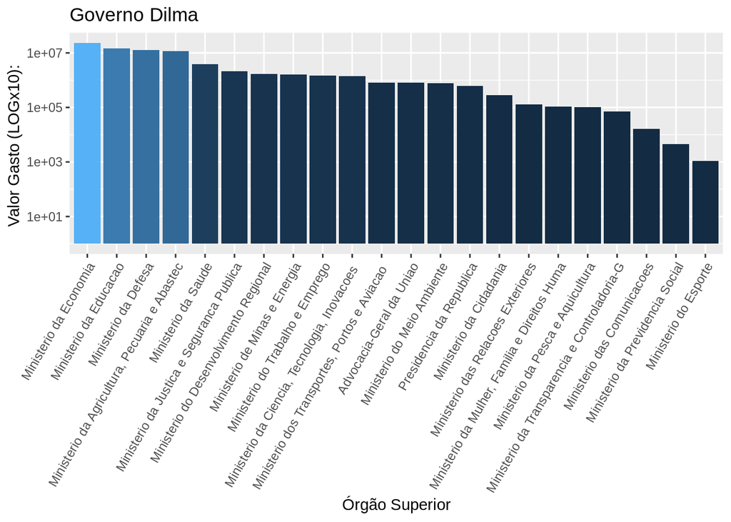

Como podemos ver acima, o Ministério dos Esportes é o setor que menos gasta comparado a todos os outros, com isto, podemos analisar mais a fundo algumas hipóteses deste baixo gasto com o cartão.

Talvez este baixo gasto financeiro com o setor esteja relacionado a despriorização do setor aos olhos do presidente, o que consequentemente diminuiria os gastos do setor, e portanto reduzindo a necessidade de compra de suprimentos. Também poderiamos aprofundar nosso estudo indo na linha de que existe um conflito político, onde a maioria entende que outros setores são prioridade.

Tudo isso são hipóteses que infelizmente não podemos concluir com 100% de certeza porque dependem de diversas outras variáveis, mas conforme mostramos no gráfico acima, podemos concluir que durante o governo Dilma, baseado em todos os registros que coletamos, o Ministério dos Esportes é o que menos gastou e o Ministério da Economia é o que mais gastou com o cartão de suprimento de fundos entre 01/01/2011 e 31/08/2016.

Vamos agora fazer a mesma análise no governo Temer, a fim de identificar os ministérios com maior e menor gasto.

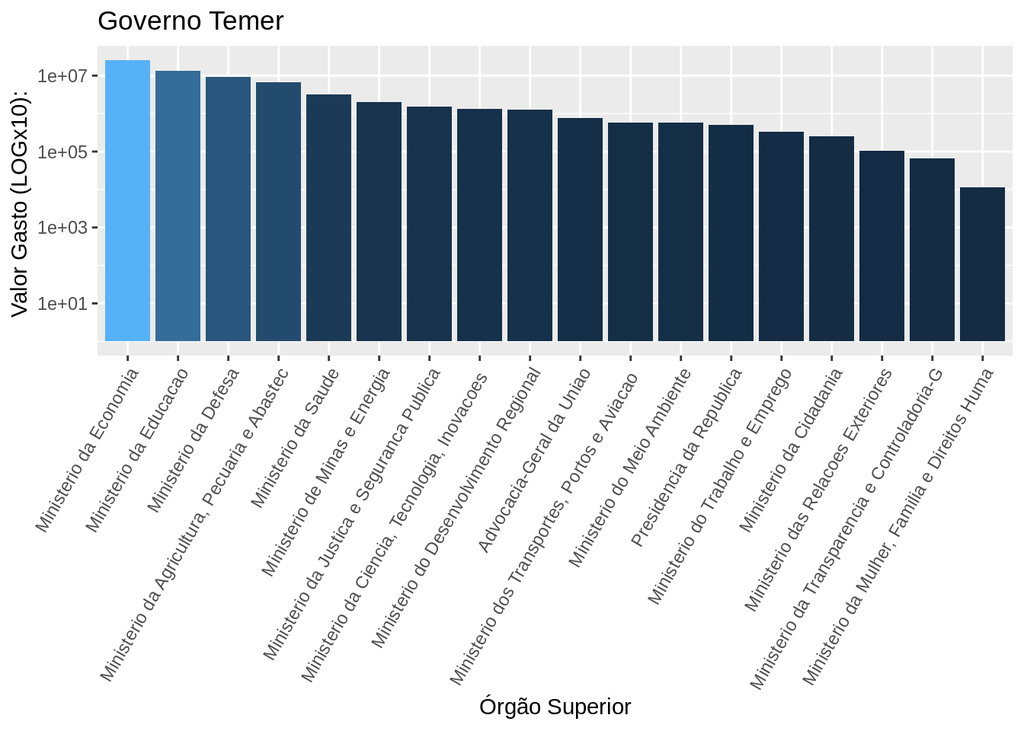

Como podemos analisar no gráfico acima, durante o governo Temer mantivemos o foco com maior gasto no Ministérior da Economia, o que provavelmente tem relação com a crise instalada no país, época em que a população realizou diversas manifestações, empresas recuaram nos investimentos, etc.

No governo temer identificamos um fato muito interessante, o governo dele apresentou um baixo gasto de suprimento de fundos no Ministerio da Mulher, Família e Direitos Humanos. Poderiamos dizer que o fato da antiga Presidente Dilma ser mulher, fez com que os setores responsáveis pelo Ministério da Mulher, Família e Direitos Humanos tenham sido priorizados durante o governo dela, o que na minha opinião faria sentido.

## Conclusão

Após realizarmos esta análise, concluimos que em ambos os governos os ministérios da Economia, Educação, Defesa e Saúde eram prioridades, e apresentavam portanto um maior gasto de suprimentos de fundos. Outro ponto levantado, e que não podemos concluir com 100% de certeza, foi que ministérios que teóricamente são de baixa prioridade para o país, apresentaram-se com prioridade diferente nos dois governos.